# Risk Factor Analysis

## Outcome Variable

**Outcome Variable:** ever_stunted

## Predictor Variables

**Intervention Variable:** mwtkg

**Adjustment Set:**

- arm
- W_mage
- meducyrs
- feducyrs
- W_nchldlt5
- brthmon
- W_parity
- delta_W_mage
- delta_meducyrs
- delta_feducyrs
- delta_W_nchldlt5
- delta_brthmon
- delta_W_parity

## Stratifying Variables

The analysis was stratified on these variable(s):

- agecat
- studyid
- country

## Data Summary

| agecat | studyid | country | mwtkg | ever_stunted | n_cell | n |
| --- | --- | --- | --- | --- | --- | --- |
| 0-24 months | ki0047075b-MAL-ED | BANGLADESH | >=58 kg | 0 | 28 | 254 |
| 0-24 months | ki0047075b-MAL-ED | BANGLADESH | >=58 kg | 1 | 20 | 254 |
| 0-24 months | ki0047075b-MAL-ED | BANGLADESH | <52 kg | 0 | 49 | 254 |
| 0-24 months | ki0047075b-MAL-ED | BANGLADESH | <52 kg | 1 | 113 | 254 |
| 0-24 months | ki0047075b-MAL-ED | BANGLADESH | [52-58) kg | 0 | 21 | 254 |
| 0-24 months | ki0047075b-MAL-ED | BANGLADESH | [52-58) kg | 1 | 23 | 254 |
| 0-24 months | ki0047075b-MAL-ED | BRAZIL | >=58 kg | 0 | 106 | 221 |
| 0-24 months | ki0047075b-MAL-ED | BRAZIL | >=58 kg | 1 | 37 | 221 |
| 0-24 months | ki0047075b-MAL-ED | BRAZIL | <52 kg | 0 | 30 | 221 |
| 0-24 months | ki0047075b-MAL-ED | BRAZIL | <52 kg | 1 | 12 | 221 |
| 0-24 months | ki0047075b-MAL-ED | BRAZIL | [52-58) kg | 0 | 28 | 221 |
| 0-24 months | ki0047075b-MAL-ED | BRAZIL | [52-58) kg | 1 | 8 | 221 |
| 0-24 months | ki0047075b-MAL-ED | INDIA | >=58 kg | 0 | 22 | 242 |
| 0-24 months | ki0047075b-MAL-ED | INDIA | >=58 kg | 1 | 20 | 242 |
| 0-24 months | ki0047075b-MAL-ED | INDIA | <52 kg | 0 | 50 | 242 |
| 0-24 months | ki0047075b-MAL-ED | INDIA | <52 kg | 1 | 100 | 242 |
| 0-24 months | ki0047075b-MAL-ED | INDIA | [52-58) kg | 0 | 21 | 242 |
| 0-24 months | ki0047075b-MAL-ED | INDIA | [52-58) kg | 1 | 29 | 242 |
| 0-24 months | ki0047075b-MAL-ED | NEPAL | >=58 kg | 0 | 58 | 238 |
| 0-24 months | ki0047075b-MAL-ED | NEPAL | >=58 kg | 1 | 22 | 238 |
| 0-24 months | ki0047075b-MAL-ED | NEPAL | <52 kg | 0 | 37 | 238 |
| 0-24 months | ki0047075b-MAL-ED | NEPAL | <52 kg | 1 | 39 | 238 |
| 0-24 months | ki0047075b-MAL-ED | NEPAL | [52-58) kg | 0 | 60 | 238 |
| 0-24 months | ki0047075b-MAL-ED | NEPAL | [52-58) kg | 1 | 22 | 238 |
| 0-24 months | ki0047075b-MAL-ED | PERU | >=58 kg | 0 | 42 | 290 |
| 0-24 months | ki0047075b-MAL-ED | PERU | >=58 kg | 1 | 62 | 290 |
| 0-24 months | ki0047075b-MAL-ED | PERU | <52 kg | 0 | 42 | 290 |
| 0-24 months | ki0047075b-MAL-ED | PERU | <52 kg | 1 | 73 | 290 |
| 0-24 months | ki0047075b-MAL-ED | PERU | [52-58) kg | 0 | 20 | 290 |
| 0-24 months | ki0047075b-MAL-ED | PERU | [52-58) kg | 1 | 51 | 290 |

[output cut: 270 more lines]

The following strata were considered:

- agecat: 0-24 months, studyid: ki0047075b-MAL-ED, country: BANGLADESH
- agecat: 0-24 months, studyid: ki0047075b-MAL-ED, country: BRAZIL
- agecat: 0-24 months, studyid: ki0047075b-MAL-ED, country: INDIA
- agecat: 0-24 months, studyid: ki0047075b-MAL-ED, country: NEPAL
- agecat: 0-24 months, studyid: ki0047075b-MAL-ED, country: PERU
- agecat: 0-24 months, studyid: ki0047075b-MAL-ED, country: SOUTH AFRICA
- agecat: 0-24 months, studyid: ki0047075b-MAL-ED, country: TANZANIA, UNITED REPUBLIC OF
- agecat: 0-24 months, studyid: ki1000304b-SAS-CompFeed, country: INDIA
- agecat: 0-24 months, studyid: ki1017093-NIH-Birth, country: BANGLADESH
- agecat: 0-24 months, studyid: ki1017093b-PROVIDE, country: BANGLADESH
- agecat: 0-24 months, studyid: ki1017093c-NIH-Crypto, country: BANGLADESH
- agecat: 0-24 months, studyid: ki1066203-TanzaniaChild2, country: TANZANIA, UNITED REPUBLIC OF
- agecat: 0-24 months, studyid: ki1112895-iLiNS-Zinc, country: BURKINA FASO
- agecat: 0-24 months, studyid: ki1119695-PROBIT, country: BELARUS
- agecat: 0-24 months, studyid: ki1126311-ZVITAMBO, country: ZIMBABWE
- agecat: 0-24 months, studyid: ki1148112-LCNI-5, country: MALAWI
- agecat: 0-24 months, studyid: kiGH5241-JiVitA-3, country: BANGLADESH
- agecat: 0-6 months, studyid: ki0047075b-MAL-ED, country: BANGLADESH
- agecat: 0-6 months, studyid: ki0047075b-MAL-ED, country: BRAZIL
- agecat: 0-6 months, studyid: ki0047075b-MAL-ED, country: INDIA
- agecat: 0-6 months, studyid: ki0047075b-MAL-ED, country: NEPAL
- agecat: 0-6 months, studyid: ki0047075b-MAL-ED, country: PERU
- agecat: 0-6 months, studyid: ki0047075b-MAL-ED, country: SOUTH AFRICA
- agecat: 0-6 months, studyid: ki0047075b-MAL-ED, country: TANZANIA, UNITED REPUBLIC OF
- agecat: 0-6 months, studyid: ki1000304b-SAS-CompFeed, country: INDIA
- agecat: 0-6 months, studyid: ki1017093-NIH-Birth, country: BANGLADESH
- agecat: 0-6 months, studyid: ki1017093b-PROVIDE, country: BANGLADESH
- agecat: 0-6 months, studyid: ki1017093c-NIH-Crypto, country: BANGLADESH
- agecat: 0-6 months, studyid: ki1066203-TanzaniaChild2, country: TANZANIA, UNITED REPUBLIC OF
- agecat: 0-6 months, studyid: ki1119695-PROBIT, country: BELARUS
- agecat: 0-6 months, studyid: ki1126311-ZVITAMBO, country: ZIMBABWE
- agecat: 0-6 months, studyid: ki1148112-LCNI-5, country: MALAWI
- agecat: 0-6 months, studyid: kiGH5241-JiVitA-3, country: BANGLADESH
- agecat: 6-24 months, studyid: ki0047075b-MAL-ED, country: BANGLADESH
- agecat: 6-24 months, studyid: ki0047075b-MAL-ED, country: BRAZIL
- agecat: 6-24 months, studyid: ki0047075b-MAL-ED, country: INDIA
- agecat: 6-24 months, studyid: ki0047075b-MAL-ED, country: NEPAL
- agecat: 6-24 months, studyid: ki0047075b-MAL-ED, country: PERU
- agecat: 6-24 months, studyid: ki0047075b-MAL-ED, country: SOUTH AFRICA
- agecat: 6-24 months, studyid: ki0047075b-MAL-ED, country: TANZANIA, UNITED REPUBLIC OF
- agecat: 6-24 months, studyid: ki1000304b-SAS-CompFeed, country: INDIA
- agecat: 6-24 months, studyid: ki1017093-NIH-Birth, country: BANGLADESH
- agecat: 6-24 months, studyid: ki1017093b-PROVIDE, country: BANGLADESH
- agecat: 6-24 months, studyid: ki1017093c-NIH-Crypto, country: BANGLADESH
- agecat: 6-24 months, studyid: ki1066203-TanzaniaChild2, country: TANZANIA, UNITED REPUBLIC OF
- agecat: 6-24 months, studyid: ki1112895-iLiNS-Zinc, country: BURKINA FASO
- agecat: 6-24 months, studyid: ki1119695-PROBIT, country: BELARUS
- agecat: 6-24 months, studyid: ki1126311-ZVITAMBO, country: ZIMBABWE
- agecat: 6-24 months, studyid: ki1148112-LCNI-5, country: MALAWI
- agecat: 6-24 months, studyid: kiGH5241-JiVitA-3, country: BANGLADESH

### Dropped Strata

Some strata were dropped due to rare outcomes:

- agecat: 6-24 months, studyid: ki0047075b-MAL-ED, country: BRAZIL

## Methods Detail

We’re interested in the causal parameters $E[Y_a]$ for all values of $a \in \mathcal{A}$. These parameters represent the mean outcome if, possibly contrary to fact, we intervened to set all units to have $A=a$. Under the randomization and positivity assumptions, these are identified by the statistical parameters $\psi_a=E_W[E_{Y|A,W}(Y|A=a,W)]$. In addition, we’re interested in the mean of $Y$, $E[Y]$ under no intervention (the observed mean). We will estimate these parameters by using SuperLearner to fit the relevant likelihood factors – $E_{Y|A,W}(Y|A=a,W)$ and $p(A=a|W)$, and then updating our likelihood fit using a joint TMLE.

For unadjusted analyses ($W=\{\}$), initial likelihoods were estimated using Lrnr_glm to estimate the simple $E(Y|A)$ and Lrnr_mean to estimate $p(A)$. For adjusted analyses, a small library containing Lrnr_glmnet, Lrnr_xgboost, and Lrnr_mean was used.

Having estimated these parameters, we will then use the delta method to estimate relative risks and attributable risks relative to a prespecified baseline level of $A$.

# Results Detail

## Results Plots

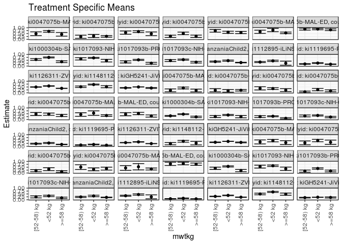

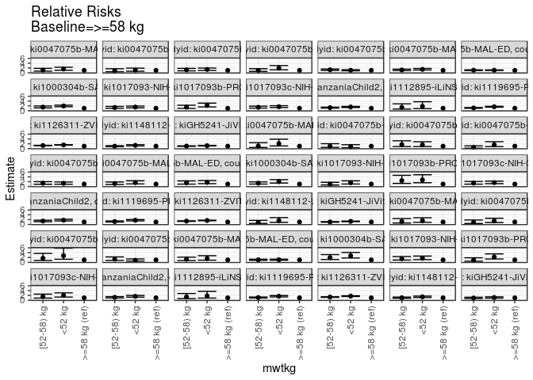

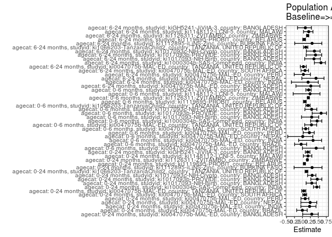

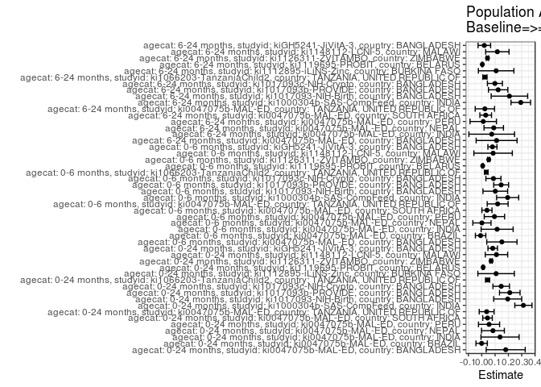

## Results Table

### Parameter: TSM

| agecat | studyid | country | intervention_level | baseline_level | estimate | ci_lower | ci_upper |
| --- | --- | --- | --- | --- | --- | --- | --- |
| 0-24 months | ki0047075b-MAL-ED | BANGLADESH | >=58 kg | NA | 0.4343610 | 0.2750785 | 0.5936434 |
| 0-24 months | ki0047075b-MAL-ED | BANGLADESH | <52 kg | NA | 0.6859273 | 0.6126782 | 0.7591764 |
| 0-24 months | ki0047075b-MAL-ED | BANGLADESH | [52-58) kg | NA | 0.4830097 | 0.3190335 | 0.6469860 |
| 0-24 months | ki0047075b-MAL-ED | BRAZIL | >=58 kg | NA | 0.2587413 | 0.1867992 | 0.3306833 |
| 0-24 months | ki0047075b-MAL-ED | BRAZIL | <52 kg | NA | 0.2857143 | 0.1487806 | 0.4226479 |
| 0-24 months | ki0047075b-MAL-ED | BRAZIL | [52-58) kg | NA | 0.2222222 | 0.0861081 | 0.3583363 |
| 0-24 months | ki0047075b-MAL-ED | INDIA | >=58 kg | NA | 0.4783550 | 0.3203214 | 0.6363886 |
| 0-24 months | ki0047075b-MAL-ED | INDIA | <52 kg | NA | 0.6657765 | 0.5900548 | 0.7414983 |
| 0-24 months | ki0047075b-MAL-ED | INDIA | [52-58) kg | NA | 0.5799365 | 0.4389723 | 0.7209006 |
| 0-24 months | ki0047075b-MAL-ED | NEPAL | >=58 kg | NA | 0.2647492 | 0.1636747 | 0.3658237 |
| 0-24 months | ki0047075b-MAL-ED | NEPAL | <52 kg | NA | 0.5112027 | 0.3987016 | 0.6237038 |
| 0-24 months | ki0047075b-MAL-ED | NEPAL | [52-58) kg | NA | 0.2619212 | 0.1639517 | 0.3598906 |
| 0-24 months | ki0047075b-MAL-ED | PERU | >=58 kg | NA | 0.5864853 | 0.4896672 | 0.6833034 |
| 0-24 months | ki0047075b-MAL-ED | PERU | <52 kg | NA | 0.6077475 | 0.5165719 | 0.6989232 |
| 0-24 months | ki0047075b-MAL-ED | PERU | [52-58) kg | NA | 0.7348641 | 0.6176908 | 0.8520374 |
| 0-24 months | ki0047075b-MAL-ED | SOUTH AFRICA | >=58 kg | NA | 0.5567010 | 0.4866665 | 0.6267356 |
| 0-24 months | ki0047075b-MAL-ED | SOUTH AFRICA | <52 kg | NA | 0.8000000 | 0.6565987 | 0.9434013 |
| 0-24 months | ki0047075b-MAL-ED | SOUTH AFRICA | [52-58) kg | NA | 0.6521739 | 0.5142823 | 0.7900655 |
| 0-24 months | ki0047075b-MAL-ED | TANZANIA, UNITED REPUBLIC OF | >=58 kg | NA | 0.8265306 | 0.7514158 | 0.9016455 |
| 0-24 months | ki0047075b-MAL-ED | TANZANIA, UNITED REPUBLIC OF | <52 kg | NA | 0.8888889 | 0.8268616 | 0.9509162 |
| 0-24 months | ki0047075b-MAL-ED | TANZANIA, UNITED REPUBLIC OF | [52-58) kg | NA | 0.8813559 | 0.7986816 | 0.9640303 |
| 0-24 months | ki1000304b-SAS-CompFeed | INDIA | >=58 kg | NA | 0.3786071 | 0.3025605 | 0.4546536 |
| 0-24 months | ki1000304b-SAS-CompFeed | INDIA | <52 kg | NA | 0.7443220 | 0.7017607 | 0.7868833 |
| 0-24 months | ki1000304b-SAS-CompFeed | INDIA | [52-58) kg | NA | 0.5678964 | 0.4959646 | 0.6398282 |
| 0-24 months | ki1017093-NIH-Birth | BANGLADESH | >=58 kg | NA | 0.4697126 | 0.3564562 | 0.5829690 |
| 0-24 months | ki1017093-NIH-Birth | BANGLADESH | <52 kg | NA | 0.7078043 | 0.6657556 | 0.7498529 |
| 0-24 months | ki1017093-NIH-Birth | BANGLADESH | [52-58) kg | NA | 0.6225248 | 0.5232267 | 0.7218228 |
| 0-24 months | ki1017093b-PROVIDE | BANGLADESH | >=58 kg | NA | 0.2425521 | 0.1607537 | 0.3243505 |
| 0-24 months | ki1017093b-PROVIDE | BANGLADESH | <52 kg | NA | 0.5372917 | 0.4900173 | 0.5845661 |
| 0-24 months | ki1017093b-PROVIDE | BANGLADESH | [52-58) kg | NA | 0.3608731 | 0.2681855 | 0.4535606 |

[output cut: 117 more lines]

### Parameter: E(Y)

| agecat | studyid | country | intervention_level | baseline_level | estimate | ci_lower | ci_upper |
| --- | --- | --- | --- | --- | --- | --- | --- |
| 0-24 months | ki0047075b-MAL-ED | BANGLADESH | NA | NA | 0.6141732 | 0.5541901 | 0.6741564 |
| 0-24 months | ki0047075b-MAL-ED | BRAZIL | NA | NA | 0.2579186 | 0.2001084 | 0.3157287 |
| 0-24 months | ki0047075b-MAL-ED | INDIA | NA | NA | 0.6157025 | 0.5542897 | 0.6771153 |
| 0-24 months | ki0047075b-MAL-ED | NEPAL | NA | NA | 0.3487395 | 0.2880656 | 0.4094134 |
| 0-24 months | ki0047075b-MAL-ED | PERU | NA | NA | 0.6413793 | 0.5860858 | 0.6966728 |
| 0-24 months | ki0047075b-MAL-ED | SOUTH AFRICA | NA | NA | 0.6000000 | 0.5414566 | 0.6585434 |
| 0-24 months | ki0047075b-MAL-ED | TANZANIA, UNITED REPUBLIC OF | NA | NA | 0.8632812 | 0.8211147 | 0.9054478 |
| 0-24 months | ki1000304b-SAS-CompFeed | INDIA | NA | NA | 0.6910891 | 0.6503148 | 0.7318634 |
| 0-24 months | ki1017093-NIH-Birth | BANGLADESH | NA | NA | 0.6645469 | 0.6276196 | 0.7014742 |
| 0-24 months | ki1017093b-PROVIDE | BANGLADESH | NA | NA | 0.4529148 | 0.4151667 | 0.4906629 |
| 0-24 months | ki1017093c-NIH-Crypto | BANGLADESH | NA | NA | 0.4794702 | 0.4438115 | 0.5151289 |
| 0-24 months | ki1066203-TanzaniaChild2 | TANZANIA, UNITED REPUBLIC OF | NA | NA | 0.3465136 | 0.3272783 | 0.3657490 |
| 0-24 months | ki1112895-iLiNS-Zinc | BURKINA FASO | NA | NA | 0.3566542 | 0.3069876 | 0.4063208 |
| 0-24 months | ki1119695-PROBIT | BELARUS | NA | NA | 0.1694743 | 0.1504830 | 0.1884655 |
| 0-24 months | ki1126311-ZVITAMBO | ZIMBABWE | NA | NA | 0.4563549 | 0.4471315 | 0.4655783 |
| 0-24 months | ki1148112-LCNI-5 | MALAWI | NA | NA | 0.6360382 | 0.6034429 | 0.6686335 |
| 0-24 months | kiGH5241-JiVitA-3 | BANGLADESH | NA | NA | 0.4953670 | 0.4875503 | 0.5031837 |
| 0-6 months | ki0047075b-MAL-ED | BANGLADESH | NA | NA | 0.3503937 | 0.2916054 | 0.4091820 |
| 0-6 months | ki0047075b-MAL-ED | BRAZIL | NA | NA | 0.2081448 | 0.1544982 | 0.2617914 |
| 0-6 months | ki0047075b-MAL-ED | INDIA | NA | NA | 0.3471074 | 0.2870050 | 0.4072099 |
| 0-6 months | ki0047075b-MAL-ED | NEPAL | NA | NA | 0.1764706 | 0.1279362 | 0.2250050 |
| 0-6 months | ki0047075b-MAL-ED | PERU | NA | NA | 0.4413793 | 0.3841309 | 0.4986278 |
| 0-6 months | ki0047075b-MAL-ED | SOUTH AFRICA | NA | NA | 0.3851852 | 0.3270313 | 0.4433391 |
| 0-6 months | ki0047075b-MAL-ED | TANZANIA, UNITED REPUBLIC OF | NA | NA | 0.4218750 | 0.3612599 | 0.4824901 |
| 0-6 months | ki1000304b-SAS-CompFeed | INDIA | NA | NA | 0.4226190 | 0.3935114 | 0.4517267 |
| 0-6 months | ki1017093-NIH-Birth | BANGLADESH | NA | NA | 0.3497615 | 0.3124631 | 0.3870600 |
| 0-6 months | ki1017093b-PROVIDE | BANGLADESH | NA | NA | 0.2481315 | 0.2153770 | 0.2808861 |
| 0-6 months | ki1017093c-NIH-Crypto | BANGLADESH | NA | NA | 0.3033113 | 0.2704998 | 0.3361228 |
| 0-6 months | ki1066203-TanzaniaChild2 | TANZANIA, UNITED REPUBLIC OF | NA | NA | 0.1943027 | 0.1783091 | 0.2102964 |
| 0-6 months | ki1119695-PROBIT | BELARUS | NA | NA | 0.0970084 | 0.0840167 | 0.1100001 |
| 0-6 months | ki1126311-ZVITAMBO | ZIMBABWE | NA | NA | 0.2824844 | 0.2741425 | 0.2908263 |
| 0-6 months | ki1148112-LCNI-5 | MALAWI | NA | NA | 0.3579336 | 0.3007518 | 0.4151153 |
| 0-6 months | kiGH5241-JiVitA-3 | BANGLADESH | NA | NA | 0.4129746 | 0.4055418 | 0.4204074 |
| 6-24 months | ki0047075b-MAL-ED | BANGLADESH | NA | NA | 0.4240506 | 0.3467471 | 0.5013542 |
| 6-24 months | ki0047075b-MAL-ED | INDIA | NA | NA | 0.4220779 | 0.3438191 | 0.5003367 |
| 6-24 months | ki0047075b-MAL-ED | NEPAL | NA | NA | 0.2113402 | 0.1537425 | 0.2689379 |
| 6-24 months | ki0047075b-MAL-ED | PERU | NA | NA | 0.3918919 | 0.3129763 | 0.4708075 |
| 6-24 months | ki0047075b-MAL-ED | SOUTH AFRICA | NA | NA | 0.3741935 | 0.2977649 | 0.4506221 |
| 6-24 months | ki0047075b-MAL-ED | TANZANIA, UNITED REPUBLIC OF | NA | NA | 0.7847222 | 0.7173567 | 0.8520877 |
| 6-24 months | ki1000304b-SAS-CompFeed | INDIA | NA | NA | 0.5030826 | 0.4587775 | 0.5473878 |
| 6-24 months | ki1017093-NIH-Birth | BANGLADESH | NA | NA | 0.5739130 | 0.5216565 | 0.6261696 |
| 6-24 months | ki1017093b-PROVIDE | BANGLADESH | NA | NA | 0.3004386 | 0.2583143 | 0.3425629 |
| 6-24 months | ki1017093c-NIH-Crypto | BANGLADESH | NA | NA | 0.2628458 | 0.2244546 | 0.3012371 |
| 6-24 months | ki1066203-TanzaniaChild2 | TANZANIA, UNITED REPUBLIC OF | NA | NA | 0.2277354 | 0.2069978 | 0.2484730 |
| 6-24 months | ki1112895-iLiNS-Zinc | BURKINA FASO | NA | NA | 0.3566542 | 0.3069876 | 0.4063208 |
| 6-24 months | ki1119695-PROBIT | BELARUS | NA | NA | 0.0803025 | 0.0658938 | 0.0947113 |
| 6-24 months | ki1126311-ZVITAMBO | ZIMBABWE | NA | NA | 0.2645703 | 0.2545045 | 0.2746362 |
| 6-24 months | ki1148112-LCNI-5 | MALAWI | NA | NA | 0.5989011 | 0.5632737 | 0.6345285 |
| 6-24 months | kiGH5241-JiVitA-3 | BANGLADESH | NA | NA | 0.2162884 | 0.2069101 | 0.2256667 |

### Parameter: RR

| agecat | studyid | country | intervention_level | baseline_level | estimate | ci_lower | ci_upper |
| --- | --- | --- | --- | --- | --- | --- | --- |
| 0-24 months | ki0047075b-MAL-ED | BANGLADESH | >=58 kg | >=58 kg | 1.0000000 | 1.0000000 | 1.000000 |
| 0-24 months | ki0047075b-MAL-ED | BANGLADESH | <52 kg | >=58 kg | 1.5791642 | 1.0753006 | 2.319128 |
| 0-24 months | ki0047075b-MAL-ED | BANGLADESH | [52-58) kg | >=58 kg | 1.1120007 | 0.6747522 | 1.832592 |
| 0-24 months | ki0047075b-MAL-ED | BRAZIL | >=58 kg | >=58 kg | 1.0000000 | 1.0000000 | 1.000000 |
| 0-24 months | ki0047075b-MAL-ED | BRAZIL | <52 kg | >=58 kg | 1.1042471 | 0.6344996 | 1.921769 |
| 0-24 months | ki0047075b-MAL-ED | BRAZIL | [52-58) kg | >=58 kg | 0.8588589 | 0.4383144 | 1.682898 |
| 0-24 months | ki0047075b-MAL-ED | INDIA | >=58 kg | >=58 kg | 1.0000000 | 1.0000000 | 1.000000 |
| 0-24 months | ki0047075b-MAL-ED | INDIA | <52 kg | >=58 kg | 1.3918042 | 0.9812078 | 1.974219 |
| 0-24 months | ki0047075b-MAL-ED | INDIA | [52-58) kg | >=58 kg | 1.2123557 | 0.8044313 | 1.827137 |
| 0-24 months | ki0047075b-MAL-ED | NEPAL | >=58 kg | >=58 kg | 1.0000000 | 1.0000000 | 1.000000 |
| 0-24 months | ki0047075b-MAL-ED | NEPAL | <52 kg | >=58 kg | 1.9308938 | 1.2412534 | 3.003698 |
| 0-24 months | ki0047075b-MAL-ED | NEPAL | [52-58) kg | >=58 kg | 0.9893179 | 0.5772880 | 1.695428 |
| 0-24 months | ki0047075b-MAL-ED | PERU | >=58 kg | >=58 kg | 1.0000000 | 1.0000000 | 1.000000 |
| 0-24 months | ki0047075b-MAL-ED | PERU | <52 kg | >=58 kg | 1.0362536 | 0.8276177 | 1.297485 |
| 0-24 months | ki0047075b-MAL-ED | PERU | [52-58) kg | >=58 kg | 1.2529966 | 0.9961886 | 1.576007 |
| 0-24 months | ki0047075b-MAL-ED | SOUTH AFRICA | >=58 kg | >=58 kg | 1.0000000 | 1.0000000 | 1.000000 |
| 0-24 months | ki0047075b-MAL-ED | SOUTH AFRICA | <52 kg | >=58 kg | 1.4370370 | 1.1544123 | 1.788854 |
| 0-24 months | ki0047075b-MAL-ED | SOUTH AFRICA | [52-58) kg | >=58 kg | 1.1714976 | 0.9159929 | 1.498272 |
| 0-24 months | ki0047075b-MAL-ED | TANZANIA, UNITED REPUBLIC OF | >=58 kg | >=58 kg | 1.0000000 | 1.0000000 | 1.000000 |
| 0-24 months | ki0047075b-MAL-ED | TANZANIA, UNITED REPUBLIC OF | <52 kg | >=58 kg | 1.0754458 | 0.9590191 | 1.206007 |
| 0-24 months | ki0047075b-MAL-ED | TANZANIA, UNITED REPUBLIC OF | [52-58) kg | >=58 kg | 1.0663319 | 0.9357728 | 1.215107 |
| 0-24 months | ki1000304b-SAS-CompFeed | INDIA | >=58 kg | >=58 kg | 1.0000000 | 1.0000000 | 1.000000 |
| 0-24 months | ki1000304b-SAS-CompFeed | INDIA | <52 kg | >=58 kg | 1.9659484 | 1.6599204 | 2.328397 |
| 0-24 months | ki1000304b-SAS-CompFeed | INDIA | [52-58) kg | >=58 kg | 1.4999626 | 1.1532467 | 1.950916 |
| 0-24 months | ki1017093-NIH-Birth | BANGLADESH | >=58 kg | >=58 kg | 1.0000000 | 1.0000000 | 1.000000 |
| 0-24 months | ki1017093-NIH-Birth | BANGLADESH | <52 kg | >=58 kg | 1.5068879 | 1.1755116 | 1.931679 |
| 0-24 months | ki1017093-NIH-Birth | BANGLADESH | [52-58) kg | >=58 kg | 1.3253311 | 0.9925866 | 1.769621 |
| 0-24 months | ki1017093b-PROVIDE | BANGLADESH | >=58 kg | >=58 kg | 1.0000000 | 1.0000000 | 1.000000 |
| 0-24 months | ki1017093b-PROVIDE | BANGLADESH | <52 kg | >=58 kg | 2.2151602 | 1.5631120 | 3.139209 |
| 0-24 months | ki1017093b-PROVIDE | BANGLADESH | [52-58) kg | >=58 kg | 1.4878168 | 0.9737355 | 2.273306 |

[output cut: 117 more lines]

### Parameter: PAR

| agecat | studyid | country | intervention_level | baseline_level | estimate | ci_lower | ci_upper |
| --- | --- | --- | --- | --- | --- | --- | --- |
| 0-24 months | ki0047075b-MAL-ED | BANGLADESH | >=58 kg | NA | 0.1798123 | 0.0334614 | 0.3261631 |
| 0-24 months | ki0047075b-MAL-ED | BRAZIL | >=58 kg | NA | -0.0008227 | -0.0434813 | 0.0418359 |
| 0-24 months | ki0047075b-MAL-ED | INDIA | >=58 kg | NA | 0.1373475 | -0.0057200 | 0.2804149 |
| 0-24 months | ki0047075b-MAL-ED | NEPAL | >=58 kg | NA | 0.0839903 | -0.0017207 | 0.1697012 |
| 0-24 months | ki0047075b-MAL-ED | PERU | >=58 kg | NA | 0.0548940 | -0.0243245 | 0.1341126 |
| 0-24 months | ki0047075b-MAL-ED | SOUTH AFRICA | >=58 kg | NA | 0.0432990 | 0.0074698 | 0.0791281 |
| 0-24 months | ki0047075b-MAL-ED | TANZANIA, UNITED REPUBLIC OF | >=58 kg | NA | 0.0367506 | -0.0189308 | 0.0924320 |
| 0-24 months | ki1000304b-SAS-CompFeed | INDIA | >=58 kg | NA | 0.3124820 | 0.2481510 | 0.3768131 |
| 0-24 months | ki1017093-NIH-Birth | BANGLADESH | >=58 kg | NA | 0.1948343 | 0.0896504 | 0.3000181 |
| 0-24 months | ki1017093b-PROVIDE | BANGLADESH | >=58 kg | NA | 0.2103627 | 0.1333471 | 0.2873784 |
| 0-24 months | ki1017093c-NIH-Crypto | BANGLADESH | >=58 kg | NA | 0.1460822 | 0.0840610 | 0.2081035 |
| 0-24 months | ki1066203-TanzaniaChild2 | TANZANIA, UNITED REPUBLIC OF | >=58 kg | NA | 0.0439922 | 0.0286591 | 0.0593252 |
| 0-24 months | ki1112895-iLiNS-Zinc | BURKINA FASO | >=58 kg | NA | 0.1077991 | -0.0291438 | 0.2447421 |
| 0-24 months | ki1119695-PROBIT | BELARUS | >=58 kg | NA | 0.0104590 | 0.0058315 | 0.0150865 |
| 0-24 months | ki1126311-ZVITAMBO | ZIMBABWE | >=58 kg | NA | 0.0704803 | 0.0614282 | 0.0795325 |
| 0-24 months | ki1148112-LCNI-5 | MALAWI | >=58 kg | NA | 0.1104009 | 0.0262340 | 0.1945678 |
| 0-24 months | kiGH5241-JiVitA-3 | BANGLADESH | >=58 kg | NA | 0.0822278 | 0.0465591 | 0.1178965 |
| 0-6 months | ki0047075b-MAL-ED | BANGLADESH | >=58 kg | NA | 0.1510763 | 0.0376452 | 0.2645073 |
| 0-6 months | ki0047075b-MAL-ED | BRAZIL | >=58 kg | NA | -0.0086384 | -0.0477583 | 0.0304815 |
| 0-6 months | ki0047075b-MAL-ED | INDIA | >=58 kg | NA | 0.1154318 | -0.0047845 | 0.2356482 |
| 0-6 months | ki0047075b-MAL-ED | NEPAL | >=58 kg | NA | 0.0014706 | -0.0666265 | 0.0695677 |
| 0-6 months | ki0047075b-MAL-ED | PERU | >=58 kg | NA | 0.0951788 | 0.0188338 | 0.1715238 |
| 0-6 months | ki0047075b-MAL-ED | SOUTH AFRICA | >=58 kg | NA | 0.0389897 | 0.0009941 | 0.0769854 |
| 0-6 months | ki0047075b-MAL-ED | TANZANIA, UNITED REPUBLIC OF | >=58 kg | NA | 0.1193904 | 0.0409008 | 0.1978801 |
| 0-6 months | ki1000304b-SAS-CompFeed | INDIA | >=58 kg | NA | 0.1945356 | 0.1117394 | 0.2773317 |
| 0-6 months | ki1017093-NIH-Birth | BANGLADESH | >=58 kg | NA | 0.1016565 | 0.0090375 | 0.1942756 |
| 0-6 months | ki1017093b-PROVIDE | BANGLADESH | >=58 kg | NA | 0.1456230 | 0.0897655 | 0.2014806 |
| 0-6 months | ki1017093c-NIH-Crypto | BANGLADESH | >=58 kg | NA | 0.0876625 | 0.0310369 | 0.1442882 |
| 0-6 months | ki1066203-TanzaniaChild2 | TANZANIA, UNITED REPUBLIC OF | >=58 kg | NA | 0.0340700 | 0.0209524 | 0.0471875 |
| 0-6 months | ki1119695-PROBIT | BELARUS | >=58 kg | NA | 0.0072344 | 0.0031103 | 0.0113585 |
| 0-6 months | ki1126311-ZVITAMBO | ZIMBABWE | >=58 kg | NA | 0.0523565 | 0.0441671 | 0.0605460 |
| 0-6 months | ki1148112-LCNI-5 | MALAWI | >=58 kg | NA | 0.0852063 | -0.0590172 | 0.2294298 |
| 0-6 months | kiGH5241-JiVitA-3 | BANGLADESH | >=58 kg | NA | 0.0801587 | 0.0460685 | 0.1142488 |
| 6-24 months | ki0047075b-MAL-ED | BANGLADESH | >=58 kg | NA | 0.1115418 | -0.0420125 | 0.2650960 |
| 6-24 months | ki0047075b-MAL-ED | INDIA | >=58 kg | NA | 0.0749609 | -0.0962988 | 0.2462206 |
| 6-24 months | ki0047075b-MAL-ED | NEPAL | >=58 kg | NA | 0.0901281 | 0.0172641 | 0.1629921 |
| 6-24 months | ki0047075b-MAL-ED | PERU | >=58 kg | NA | 0.0113570 | -0.0877754 | 0.1104894 |
| 6-24 months | ki0047075b-MAL-ED | SOUTH AFRICA | >=58 kg | NA | 0.0296557 | -0.0140735 | 0.0733850 |
| 6-24 months | ki0047075b-MAL-ED | TANZANIA, UNITED REPUBLIC OF | >=58 kg | NA | 0.0235282 | -0.0490455 | 0.0961019 |
| 6-24 months | ki1000304b-SAS-CompFeed | INDIA | >=58 kg | NA | 0.2929306 | 0.2195259 | 0.3663354 |
| 6-24 months | ki1017093-NIH-Birth | BANGLADESH | >=58 kg | NA | 0.2076949 | 0.0707535 | 0.3446364 |
| 6-24 months | ki1017093b-PROVIDE | BANGLADESH | >=58 kg | NA | 0.1230758 | 0.0503055 | 0.1958461 |
| 6-24 months | ki1017093c-NIH-Crypto | BANGLADESH | >=58 kg | NA | 0.0987778 | 0.0424549 | 0.1551006 |
| 6-24 months | ki1066203-TanzaniaChild2 | TANZANIA, UNITED REPUBLIC OF | >=58 kg | NA | 0.0238936 | 0.0084214 | 0.0393658 |
| 6-24 months | ki1112895-iLiNS-Zinc | BURKINA FASO | >=58 kg | NA | 0.1079787 | -0.0253172 | 0.2412746 |
| 6-24 months | ki1119695-PROBIT | BELARUS | >=58 kg | NA | 0.0043274 | 0.0010251 | 0.0076298 |
| 6-24 months | ki1126311-ZVITAMBO | ZIMBABWE | >=58 kg | NA | 0.0431879 | 0.0339269 | 0.0524489 |
| 6-24 months | ki1148112-LCNI-5 | MALAWI | >=58 kg | NA | 0.1171630 | 0.0292769 | 0.2050490 |
| 6-24 months | kiGH5241-JiVitA-3 | BANGLADESH | >=58 kg | NA | 0.0194255 | -0.0276069 | 0.0664578 |

### Parameter: PAF

| agecat | studyid | country | intervention_level | baseline_level | estimate | ci_lower | ci_upper |
| --- | --- | --- | --- | --- | --- | --- | --- |
| 0-24 months | ki0047075b-MAL-ED | BANGLADESH | >=58 kg | NA | 0.2927712 | 0.0062217 | 0.4966961 |
| 0-24 months | ki0047075b-MAL-ED | BRAZIL | >=58 kg | NA | -0.0031898 | -0.1830006 | 0.1492905 |
| 0-24 months | ki0047075b-MAL-ED | INDIA | >=58 kg | NA | 0.2230744 | -0.0504611 | 0.4253825 |
| 0-24 months | ki0047075b-MAL-ED | NEPAL | >=58 kg | NA | 0.2408395 | -0.0497997 | 0.4510147 |
| 0-24 months | ki0047075b-MAL-ED | PERU | >=58 kg | NA | 0.0855875 | -0.0469469 | 0.2013441 |
| 0-24 months | ki0047075b-MAL-ED | SOUTH AFRICA | >=58 kg | NA | 0.0721649 | 0.0097011 | 0.1306889 |
| 0-24 months | ki0047075b-MAL-ED | TANZANIA, UNITED REPUBLIC OF | >=58 kg | NA | 0.0425709 | -0.0245477 | 0.1052924 |
| 0-24 months | ki1000304b-SAS-CompFeed | INDIA | >=58 kg | NA | 0.4521588 | 0.3463446 | 0.5408438 |
| 0-24 months | ki1017093-NIH-Birth | BANGLADESH | >=58 kg | NA | 0.2931836 | 0.1136933 | 0.4363245 |
| 0-24 months | ki1017093b-PROVIDE | BANGLADESH | >=58 kg | NA | 0.4644642 | 0.2643563 | 0.6101393 |
| 0-24 months | ki1017093c-NIH-Crypto | BANGLADESH | >=58 kg | NA | 0.3046742 | 0.1615673 | 0.4233552 |
| 0-24 months | ki1066203-TanzaniaChild2 | TANZANIA, UNITED REPUBLIC OF | >=58 kg | NA | 0.1269565 | 0.0816206 | 0.1700544 |
| 0-24 months | ki1112895-iLiNS-Zinc | BURKINA FASO | >=58 kg | NA | 0.3022511 | -0.2635259 | 0.6146866 |
| 0-24 months | ki1119695-PROBIT | BELARUS | >=58 kg | NA | 0.0617143 | 0.0317743 | 0.0907284 |
| 0-24 months | ki1126311-ZVITAMBO | ZIMBABWE | >=58 kg | NA | 0.1544419 | 0.1342660 | 0.1741477 |
| 0-24 months | ki1148112-LCNI-5 | MALAWI | >=58 kg | NA | 0.1735759 | 0.0294632 | 0.2962897 |
| 0-24 months | kiGH5241-JiVitA-3 | BANGLADESH | >=58 kg | NA | 0.1659937 | 0.0908767 | 0.2349041 |
| 0-6 months | ki0047075b-MAL-ED | BANGLADESH | >=58 kg | NA | 0.4311615 | 0.0007074 | 0.6761937 |
| 0-6 months | ki0047075b-MAL-ED | BRAZIL | >=58 kg | NA | -0.0415020 | -0.2473085 | 0.1303464 |
| 0-6 months | ki0047075b-MAL-ED | INDIA | >=58 kg | NA | 0.3325536 | -0.1194883 | 0.6020640 |
| 0-6 months | ki0047075b-MAL-ED | NEPAL | >=58 kg | NA | 0.0083333 | -0.4633876 | 0.3279957 |
| 0-6 months | ki0047075b-MAL-ED | PERU | >=58 kg | NA | 0.2156395 | 0.0224534 | 0.3706475 |
| 0-6 months | ki0047075b-MAL-ED | SOUTH AFRICA | >=58 kg | NA | 0.1012234 | -0.0032649 | 0.1948294 |
| 0-6 months | ki0047075b-MAL-ED | TANZANIA, UNITED REPUBLIC OF | >=58 kg | NA | 0.2829995 | 0.0699472 | 0.4472467 |
| 0-6 months | ki1000304b-SAS-CompFeed | INDIA | >=58 kg | NA | 0.4603095 | 0.2548178 | 0.6091348 |
| 0-6 months | ki1017093-NIH-Birth | BANGLADESH | >=58 kg | NA | 0.2906453 | -0.0301407 | 0.5115385 |
| 0-6 months | ki1017093b-PROVIDE | BANGLADESH | >=58 kg | NA | 0.5868784 | 0.3040714 | 0.7547601 |
| 0-6 months | ki1017093c-NIH-Crypto | BANGLADESH | >=58 kg | NA | 0.2890184 | 0.0766906 | 0.4525185 |
| 0-6 months | ki1066203-TanzaniaChild2 | TANZANIA, UNITED REPUBLIC OF | >=58 kg | NA | 0.1753447 | 0.1060438 | 0.2392733 |
| 0-6 months | ki1119695-PROBIT | BELARUS | >=58 kg | NA | 0.0745751 | 0.0301998 | 0.1169200 |
| 0-6 months | ki1126311-ZVITAMBO | ZIMBABWE | >=58 kg | NA | 0.1853431 | 0.1560277 | 0.2136402 |
| 0-6 months | ki1148112-LCNI-5 | MALAWI | >=58 kg | NA | 0.2380506 | -0.2925147 | 0.5508238 |
| 0-6 months | kiGH5241-JiVitA-3 | BANGLADESH | >=58 kg | NA | 0.1941007 | 0.1073095 | 0.2724537 |
| 6-24 months | ki0047075b-MAL-ED | BANGLADESH | >=58 kg | NA | 0.2630388 | -0.2054727 | 0.5494616 |
| 6-24 months | ki0047075b-MAL-ED | INDIA | >=58 kg | NA | 0.1775997 | -0.3487725 | 0.4985498 |
| 6-24 months | ki0047075b-MAL-ED | NEPAL | >=58 kg | NA | 0.4264597 | -0.0212821 | 0.6779064 |
| 6-24 months | ki0047075b-MAL-ED | PERU | >=58 kg | NA | 0.0289799 | -0.2599690 | 0.2516641 |
| 6-24 months | ki0047075b-MAL-ED | SOUTH AFRICA | >=58 kg | NA | 0.0792524 | -0.0454791 | 0.1891027 |
| 6-24 months | ki0047075b-MAL-ED | TANZANIA, UNITED REPUBLIC OF | >=58 kg | NA | 0.0299828 | -0.0672917 | 0.1183916 |
| 6-24 months | ki1000304b-SAS-CompFeed | INDIA | >=58 kg | NA | 0.5822715 | 0.3749845 | 0.7208115 |
| 6-24 months | ki1017093-NIH-Birth | BANGLADESH | >=58 kg | NA | 0.3618927 | 0.0691824 | 0.5625556 |
| 6-24 months | ki1017093b-PROVIDE | BANGLADESH | >=58 kg | NA | 0.4096538 | 0.1153167 | 0.6060640 |
| 6-24 months | ki1017093c-NIH-Crypto | BANGLADESH | >=58 kg | NA | 0.3758012 | 0.1232621 | 0.5555979 |
| 6-24 months | ki1066203-TanzaniaChild2 | TANZANIA, UNITED REPUBLIC OF | >=58 kg | NA | 0.1049183 | 0.0346897 | 0.1700375 |
| 6-24 months | ki1112895-iLiNS-Zinc | BURKINA FASO | >=58 kg | NA | 0.3027547 | -0.2446756 | 0.6094155 |
| 6-24 months | ki1119695-PROBIT | BELARUS | >=58 kg | NA | 0.0538893 | 0.0099620 | 0.0958675 |
| 6-24 months | ki1126311-ZVITAMBO | ZIMBABWE | >=58 kg | NA | 0.1632379 | 0.1277043 | 0.1973241 |
| 6-24 months | ki1148112-LCNI-5 | MALAWI | >=58 kg | NA | 0.1956299 | 0.0339415 | 0.3302567 |
| 6-24 months | kiGH5241-JiVitA-3 | BANGLADESH | >=58 kg | NA | 0.0898128 | -0.1554727 | 0.2830287 |